# GLIFWC Siscowet Lake Trout Analysis

Khousheng M. Moua

22 May, 2020

# Introduction

Great Lakes Indian Fisheries and Wildlife Commission has been part of a long study of surveying, analyzing, understanding, and managing the numerous species of fish that tribal members harvest annually. Ranging from inland species, such as walleye, to Great Lakes species, such as siscowet, the studies done are compiled together to meet with the larger part, the Great Lakes Fisheries Commission, in terms of presenting data and creating and reviewing management plans for future years to come. Much appreciation to Bill Mattes for providing data for graphical and analytical purposes.

Majority of analyses here will focus mainly on siscowet lake trout within Lake Superior for the years of 1999, 2003, 2008, 2012, and 2017 due to limited data and sampling size.

# Packages and Data

```r
setwd("C:/Users/khous/Desktop/College Work/MTH/MTH 250 - Graphing/Excel Data")
library(tidyverse)
library(dplyr)
library(NCStats)
library(ggplot2)
library(plyr)
```

```r
ST5yrs <- read.csv("GLIFWC.csv") %>%
  filterD(SPECIES=="ST") %>%
  filterD(Year %in% c(1999,2003,2008,2012,2017)) %>%
  mutate(Year=factor(Year,levels=c("1999","2003","2008","2012","2017"))) %>%
  select(-ID,-SAMNUM,-GRID,-starts_with("WOUNDS"))

## Explicitly remove individuals for which an age was not recorded
ageclass <- ST5yrs %>%
  filterD(!is.na(AGE))

## Explicitly remove individs for which both a weight and length were not recorded
WL <- ST5yrs %>%
  filterD(!is.na(WEIGHT),!is.na(LENGTH))%>%
  mutate(DEPTH_BIN=factor(DEPTH_BIN,levels=c("1","2","3","4","5"))) %>%
  mutate(DEPTH_BIN2=FSA::mapvalues(DEPTH_BIN,from=c("1"),to=c("2")))
WL$log.WEIGHT <- log(WL$WEIGHT)
WL$log.LENGTH <- log(WL$LENGTH)

theme_KM <- theme_bw()+
  theme(
  axis.title = element_text(face="bold",size=rel(1.15)),
  axis.text = element_text(size=rel(1.05)),
  panel.grid.major = element_blank(),
  panel.grid.minor = element_blank(),
  panel.border=element_rect(size=0.5),
  legend.position="none",
  plot.caption = element_text(hjust=0,size=rel(1)))
```

# Analysis 1: Comparing Siscowet Age Distribution

In this first analysis, the first interest in the data was to determine how the age distribution of the siscowet lake trout (salvelinus namaycush siscowet) has shifted througout the years from 1999 - 2017 and determine possible shifts that may occur in the future based upon past years.

## Data Visualization

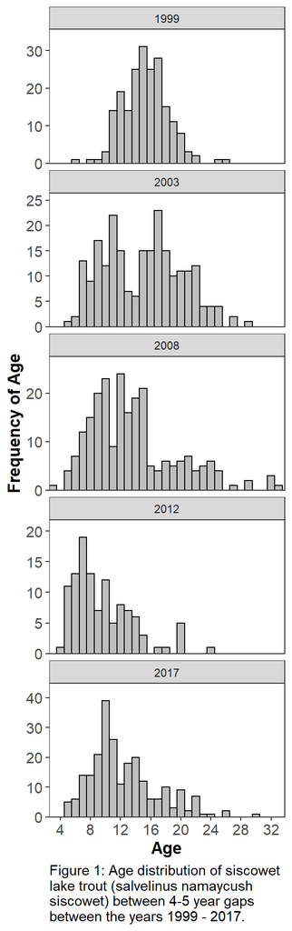

```r
c1 <- ggplot(data=ageclass, mapping=aes(x=AGE))+
  geom_histogram(color="black", fill="grey", binwidth=1)+
  facet_wrap(~Year,ncol=1, scale="free_y")+
  scale_y_continuous(name = "Frequency of Age", expand=expansion(c(0,0.15)))+
  scale_x_continuous(name = "Age", breaks=seq(0,34,4), expand=expansion(c(0,0.01)))+
  theme_KM+
  labs(caption = "Figure 1: Age distribution of siscowet
lake trout (salvelinus namaycush
siscowet) between 4-5 year gaps
between the years 1999 - 2017.")
c1
```

### Plot Summary

There are a few, but not limited, noticeable observations made that can be seen within the plot:

- As the years progress from the year 1999 to the year 2017, there is a gradual shift from older siscowet to a younger generation of fish
- There was a bimodal distribution for the year 2003
- The year 2017 shown the distribution of age shifting right once again
- At the start of 1999, there were higher numbers of siscowet at an older age which began to decrease as years went on. Upon approaching the year 2017, there numbers of siscowet increased within the younger generation compared to previous years

# Analysis 2: Comparing log Total Length and log Weight within four different depth bins for siscowet lake trout

The analysis done here is in the interests of determining how length and weight for siscowet vary among different depths within Lake Superior for five selected years. The categorical variable DEPTH_BIN is the range of depth in which the fish was captured (ex: DEPTH_BIN “1” = 0m - 99m)

One thing to note for this analysis, depth bin value of 1 has been combined with 2 due to depth bin of 1 having a low sampling size (n=7).

### Annotation through creating data frames for faceting

```r
#Using IVR to find slope and intercept
(lm1 <- lm(log.WEIGHT~log.LENGTH*DEPTH_BIN2, data=WL))
coef(lm1)

#Filtering data to find slope and intercept
WLD2 <- WL %>%
  filterD(DEPTH_BIN2==2)
(lm(log.WEIGHT~log.LENGTH, data=WLD2))

WLD3 <- WL %>%
  filterD(DEPTH_BIN2==3)
(lm(log.WEIGHT~log.LENGTH, data=WLD3))

WLD4 <- WL %>%
  filterD(DEPTH_BIN2==4)
(lm(log.WEIGHT~log.LENGTH, data=WLD4))

WLD5 <- WL %>%
  filterD(DEPTH_BIN2==5)
(lm(log.WEIGHT~log.LENGTH, data=WLD5))

#Dataframe for annotating slope equation
anno <- data.frame(x1 = c(2.5,2.55,2.22,2.65), y1 = c(8.75,8.5,8.65,8.6),
                   lab = c("y = 3.421x - 3.297", "y = 3.264x - 2.793", "y = 3.349x - 3.021", "y = 3.335x - 2.991"),
                   DEPTH_BIN2 = c("2","3","4","5"))
anno

#Dataframe for annotating outliers
anno2 <- data.frame(x1 = c(log(18),log(19),log(33.3),log(7),log(16.5),log(17.5), log(18.5), log(19.2)),
                    y1 = c(log(1800),log(1750),log(7750),log(39),log(1700), log(1700), log(1800), log(2750)),
                    DEPTH_BIN2 = c("2","2","2","4", "4","5","5","5"))
anno2

#Dataframe for annotating the total number of individuals in each plot
WL.cor <- ddply(.data=WL,
                 .(DEPTH_BIN2),
                 summarize,
                 n=paste("n =", length(log.LENGTH)))

#
```

[output not shown]

## Data Visualization

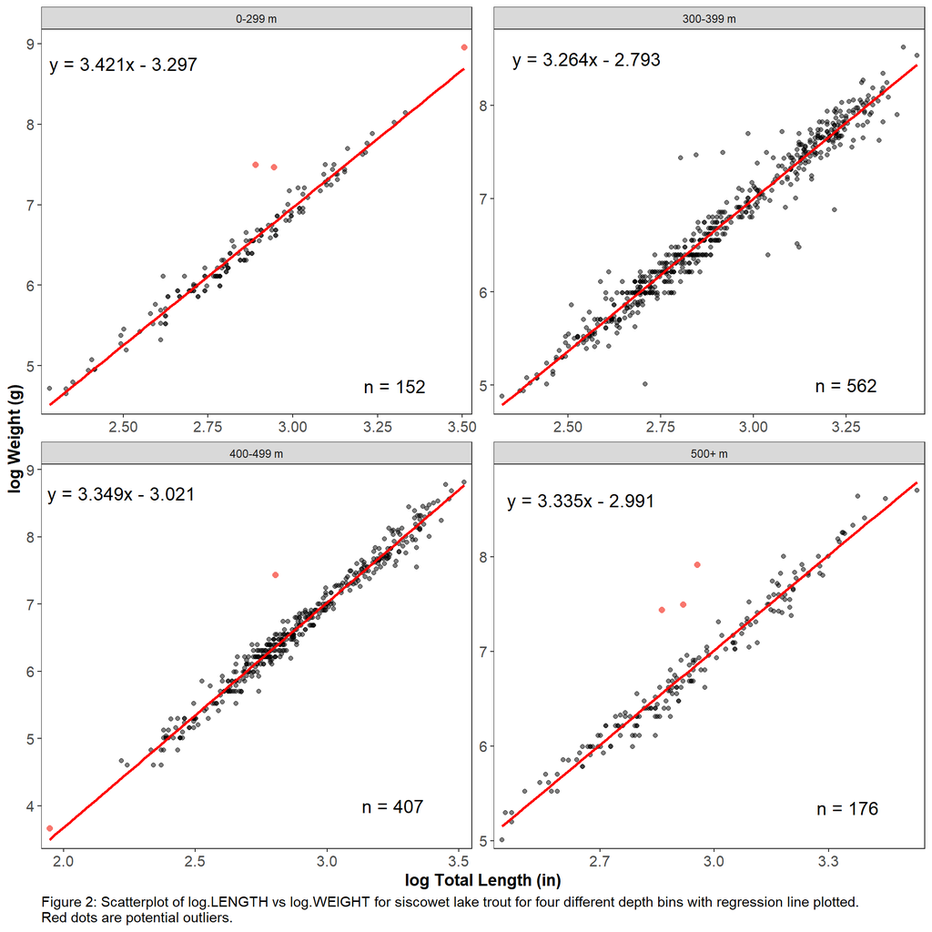

```r
c2 <- ggplot(data=WL, mapping=aes(x=log.LENGTH, y=log.WEIGHT, color=DEPTH_BIN, fill=DEPTH_BIN2))+
  geom_point(color="black", alpha=0.5)+
  geom_smooth(method=lm, color="red", se=FALSE)+
  scale_x_continuous(name= "log Total Length (in)", expand=expansion(c(0.02,0.019)))+
  scale_y_continuous(name= "log Weight (g)", expand=expansion(c(0.025,0.05)))+
  facet_wrap(~DEPTH_BIN2, nrow=2, scale = "free",labeller=labeller(DEPTH_BIN2= c("2"="0-299 m", "3"="300-399 m", "4"="400-499 m", "5"="500+ m")))+

  geom_text(data=WL.cor, aes(x=c(3.3,3.25,3.25,3.35), y=c(4.75,5,4,5.35), label=n),
                    colour="black", size=5, inherit.aes=FALSE, parse=FALSE)+
  geom_text(data=anno, aes(x=x1, y=y1, label=lab),
                    colour="black", size=5, inherit.aes=FALSE, parse=FALSE)+
  geom_point(data=anno2, aes(x=x1, y=y1, color="red"), size=2)+
  theme_KM+
  labs(caption = "Figure 2: Scatterplot of log.LENGTH vs log.WEIGHT for siscowet lake trout for four different depth bins with regression line plotted.
Red dots are potential outliers."
)
c2
```

### Plot Observations

- Observing the slopes of each one, no trends are really profound within this data analysis
- Outliers may have a substantial effect in calculating slope and the intercept for each plot at varying depths (removing may show a better log Total Length and log Weight relationship)
- Not the best way to compare relationships to one another (other suitable method may be an Indicator Variable Regression)

# Designing Process for Plots

### Histogram

- Wanted to look at age distribution of siscowet lake trout, histogram was the simpler function in mind to create it
- faceting was simpler than having to create and manage different data frames and adding them through other functions, which would be excessive and more time consuming

### Scatterplot

- wanted to show each indivdual point with a best-fit line, which lead to use of geom_point and geom_smooth
- wanted to show relationship and sampling number to provide graphical information and possibly interpretation if major trends were noticeable.
- similar to histogram, faceting simpler than creating different data frames